# 1. Human transcript biased

### Generate lists of human genes biased by the number of transcripts for the genes.

Use a gene info file derived from a gtf file from Ensembl containing all the genes and transcripts in the human genome.

| gene_name | n |
| --- | --- |
| Y_RNA | 756 |
| Metazoa_SRP | 169 |
| U3 | 51 |
| U6 | 33 |
| SNORA70 | 27 |
| U8 | 22 |
| U2 | 19 |
| U1 | 13 |
| SNORA72 | 8 |
| 7SK | 7 |

[output cut: 59 more lines]

This table show the number of times that a gene name appears in the genome annotated as a distinct gene.  
There are lots of duplicate gene names so we’ll use the Ensembl gene IDs for the initial processing.  
The gene set files that we use for the GO analysis do not contain Ensembl IDs so we’ll have to convert back to gene name at the point when we run the GO analysis.  
The highly duplicated gene names probably aren’t in the GO annotations much but it’d be worth checking.

There are 0 duplicate Ensembl IDs so we’ll use these for filtering and convert back to gene name at the end of this analysis.

## Number of transcripts per gene

| gene_id | gene_name | no_of_transcripts |
| --- | --- | --- |
| ENSG00000179818 | PCBP1-AS1 | 239 |
| ENSG00000109339 | MAPK10 | 192 |
| ENSG00000226674 | TEX41 | 189 |
| ENSG00000249859 | PVT1 | 182 |
| ENSG00000241469 | LINC00635 | 164 |
| ENSG00000227195 | MIR663AHG | 146 |
| ENSG00000215386 | MIR99AHG | 143 |
| ENSG00000242086 | MUC20-OT1 | 142 |
| ENSG00000224078 | SNHG14 | 142 |
| ENSG00000226620 | LINC00343 | 131 |

[output cut: 60554 more lines]

| no_of_transcripts | n | percentage |
| --- | --- | --- |
| 1 | 36671 | 61 |
| 2 | 4546 | 8 |
| 3 | 2972 | 5 |
| 4 | 2337 | 4 |
| 5 | 2013 | 4 |
| 6 | 1639 | 3 |
| 7 | 1474 | 3 |
| 8 | 1189 | 2 |
| 9 | 1161 | 2 |
| 10 | 901 | 2 |

[output cut: 96 more lines]

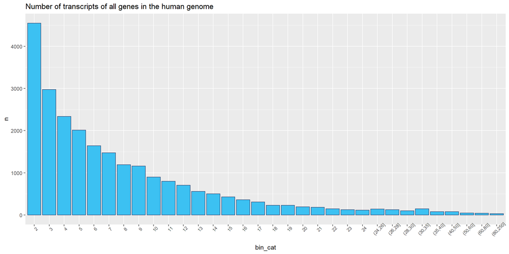

## Thresholds

| threshold | transcript_threshold | category | no_of_genes |
| --- | --- | --- | --- |
| 90% | 10 | high | 6562 |
| 95% | 15 | very_high | 3098 |
| 99% | 27 | very_very_high | 639 |

Thresholds based on the distribution of the data at 90th, 95th and 99th percentiles.

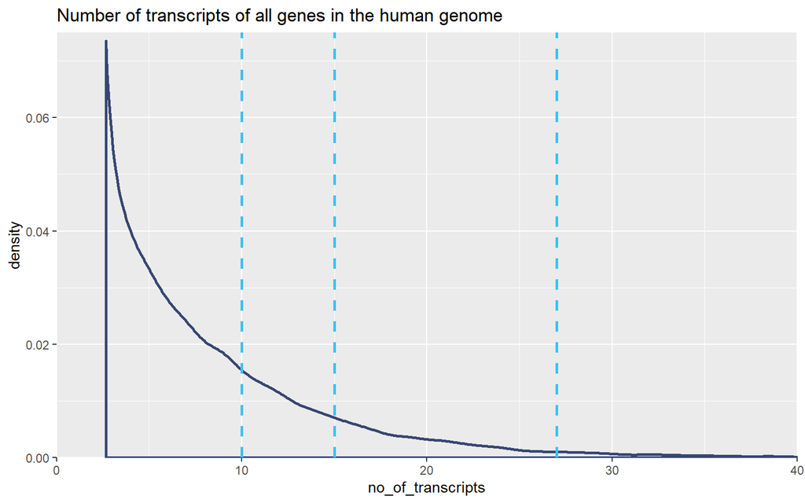

| threshold | transcript_threshold | category | no_of_genes |
| --- | --- | --- | --- |
| 90% | 10 | high | 6562 |
| 95% | 15 | very_high | 3098 |
| 99% | 27 | very_very_high | 639 |

## Generating the biased gene sets and running the GO analysis

1. Randomly select 200 genes from the subset of genes with high/very high/very very high numbers of transcripts.  
2. Run functional enrichment analysis, record results.  
3. Repeat steps 1 and 2 100 times.  
Repeat this for each transcript category.

| bias_category | n |
| --- | --- |
| high | 69 |
| very_high | 91 |
| very_very_high | 99 |

The table shows the number of functional enrichment analyses that returned 1 or more significantly enriched categories from the 100 that were run.

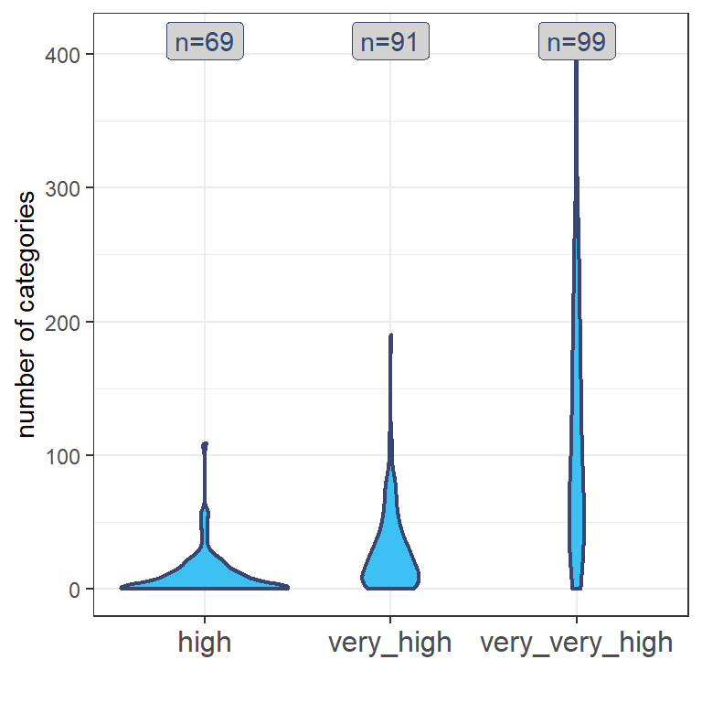

The violin plot shows the number of significant categories per gene list returned from the GO analysis.

## Identified categories

The number of times that a functional category was identified from the 100 times that the analysis was run for each bias category. The table contains every functional category that appeared once or more in any of the bias categories.

| GO_category | high | very_high | very_very_high |
| --- | --- | --- | --- |
| INTRACELLULAR PART%GOCC%GO:0044424 | 51 | 82 | 96 |
| INTRACELLULAR%GOCC%GO:0005622 | 51 | 82 | 96 |
| ORGANELLE PART%GOCC%GO:0044422 | 24 | 55 | 92 |
| CYTOPLASM%GOCC%GO:0005737 | 30 | 73 | 86 |
| INTRACELLULAR ORGANELLE PART%GOCC%GO:0044446 | 28 | 53 | 85 |
| PROTEIN BINDING%GOMF%GO:0005515 | 22 | 44 | 84 |
| CYTOSOL%GOCC%GO:0005829 | 23 | 55 | 80 |
| REGULATION OF CELLULAR COMPONENT ORGANIZATION%GOBP%GO:0051128 | 6 | 15 | 79 |
| CYTOPLASMIC PART%GOCC%GO:0044444 | 25 | 67 | 78 |
| ORGANELLE%GOCC%GO:0043226 | 36 | 55 | 78 |

[output cut: 1553 more lines]

In total, 1563 functional categories appeared at least once.

## Filter Categories

We don’t want categories that only appeared a handful of times so we’ll use an arbitrary value of 20 as a threshold.

## GO category occurrences

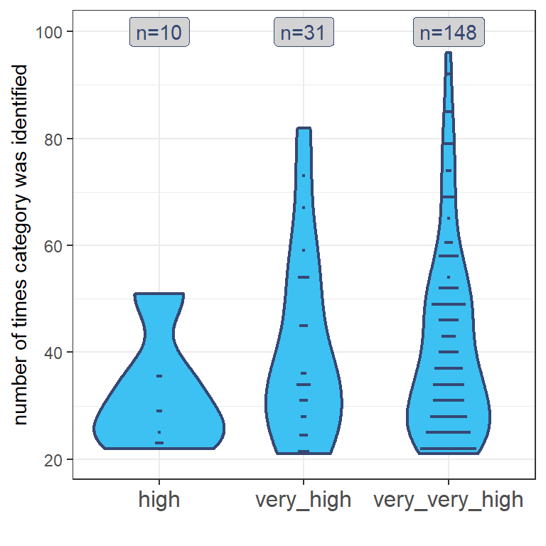

## Deduplicate terms

There are 10 functional categories that were identified in all 3 transcript categories and 18 functional categories identified in 2 transcript categories. The duplicate terms will be removed from the more stringent categories.

We don’t get as many results here, compared to mouse. Is human better curated? It would be interesting to see how many annotations human genes have compared to mouse.

Total number of functional categories tested = 13735

Laura Biggins

2020-01-14